# 第三次作业

李溦_21210980047

# 0. 准备工作

```r
# 清理工作环境
# cat("\014");rm(list = ls())
# 导入需要的安装包
library(ggplot2)
library(ggpubr)
```

# 1. 第一题

读入数据，查看数据情况

```r
# 读入数据
data <- read.csv('data.csv',header = TRUE, encoding = 'utf-8')
# 查看前几行
head(data)
```

```
##   delivery_mode float_delivery_fee float_minimum_order_amount is_new is_premium
## 1      商家配送                  7                          0  False      False
## 2      蜂鸟专送                  5                         20  False       True
## 3      商家配送                  6                         20  False       True
## 4      商家配送                 10                         20  False      False
## 5      商家配送                  7                         30  False      False
## 6      商家配送                  5                         30  False      False
##   order_lead_time recent_order_num compare_rating food_score service_score
## 1              45             2123      0.4948689    4.50012       4.47928
## 2              35             4546      0.7005511    4.61939       4.74763
## 3              51             1194      0.4664587    4.61707       4.47224
## 4              44              375      0.3758566    4.81023       4.70941
## 5              38             6664      0.5331492    4.60685       4.56124
## 6              25               54      0.9563925    4.92060       5.00000
##   star_level district manjian_discount new_user other_activities average_cost
```

[output cut: 27 more lines]

```r
# 查看汇总信息
summary(data)
```

```
##  delivery_mode      float_delivery_fee float_minimum_order_amount
##  Length:32043       Min.   :  0.000    Min.   :  0.00
##  Class :character   1st Qu.:  5.000    1st Qu.: 20.00
##  Mode  :character   Median :  7.000    Median : 20.00
##                     Mean   :  8.355    Mean   : 22.87
##                     3rd Qu.:  9.000    3rd Qu.: 20.00
##                     Max.   :200.000    Max.   :500.00
##     is_new           is_premium        order_lead_time recent_order_num
##  Length:32043       Length:32043       Min.   : 0.00   Min.   :    0.0
##  Class :character   Class :character   1st Qu.:26.00   1st Qu.:   45.0
##  Mode  :character   Mode  :character   Median :31.00   Median :  124.0
##                                        Mean   :30.32   Mean   :  465.7
##                                        3rd Qu.:37.00   3rd Qu.:  452.0
##                                        Max.   :80.00   Max.   :13571.0
##  compare_rating      food_score     service_score      star_level
##  Min.   :-1.0000   Min.   :-1.000   Min.   :-1.000   Min.   :-1.000
##  1st Qu.: 0.2792   1st Qu.: 4.341   1st Qu.: 4.401   1st Qu.: 4.400
##  Median : 0.5148   Median : 4.538   Median : 4.643   Median : 4.600
##  Mean   : 0.4472   Mean   : 4.188   Mean   : 4.272   Mean   : 4.237
##  3rd Qu.: 0.7396   3rd Qu.: 4.732   3rd Qu.: 4.834   3rd Qu.: 4.800
##  Max.   : 0.9889   Max.   : 5.000   Max.   : 5.000   Max.   : 5.000
##    district         manjian_discount    new_user     other_activities
##  Length:32043       Min.   :0.0000   Min.   : 0.00   Min.   : 0.0000
##  Class :character   1st Qu.:0.0100   1st Qu.:17.00   1st Qu.: 0.0000
##  Mode  :character   Median :0.1667   Median :20.00   Median : 0.0000
##                     Mean   :0.1975   Mean   :19.16   Mean   : 0.9727
##                     3rd Qu.:0.3231   3rd Qu.:21.00   3rd Qu.: 1.0000
##                     Max.   :0.9583   Max.   :45.00   Max.   :30.0000
##   average_cost          保              票          log_recent_order_num
##  Min.   :     0.0   Mode :logical   Mode :logical   Min.   :0.000
##  1st Qu.:    27.5   FALSE:8359      FALSE:23572     1st Qu.:3.829
##  Median :    38.5   TRUE :23684     TRUE :8471      Median :4.828
##  Mean   :    77.1                                   Mean   :4.758
##  3rd Qu.:    57.6                                   3rd Qu.:6.116
##  Max.   :655873.9                                   Max.   :9.516
##  log_average_cost log_float_minimum_order_amount log_float_delivery_fee
##  Min.   : 0.000   Min.   :0.000                  Min.   :0.000
##  1st Qu.: 3.349   1st Qu.:3.045                  1st Qu.:1.792
##  Median : 3.677   Median :3.045                  Median :2.079
##  Mean   : 3.543   Mean   :2.958                  Mean   :2.101
##  3rd Qu.: 4.070   3rd Qu.:3.045                  3rd Qu.:2.303
##  Max.   :13.394   Max.   :6.217                  Max.   :5.303
##    open_time         open08            open12           open18
##  Min.   : 0.00   Min.   :0.00000   Min.   :0.0000   Min.   :0.0000
##  1st Qu.:10.83   1st Qu.:0.00000   1st Qu.:1.0000   1st Qu.:1.0000
##  Median :11.75   Median :0.00000   Median :1.0000   Median :1.0000
##  Mean   :11.90   Mean   :0.05564   Mean   :0.9621   Mean   :0.9846
##  3rd Qu.:12.50   3rd Qu.:0.00000   3rd Qu.:1.0000   3rd Qu.:1.0000
##  Max.   :24.00   Max.   :1.00000   Max.   :1.0000   Max.   :1.0000
##      open23        shop_type          district0
##  Min.   :0.0000   Length:32043       Length:32043
##  1st Qu.:0.0000   Class :character   Class :character
##  Median :0.0000   Mode  :character   Mode  :character
##  Mean   :0.1536
##  3rd Qu.:0.0000
##  Max.   :1.0000
```

# 2. 第二题

绘制对数月销量的直方图，观察其特征，并作出解释；

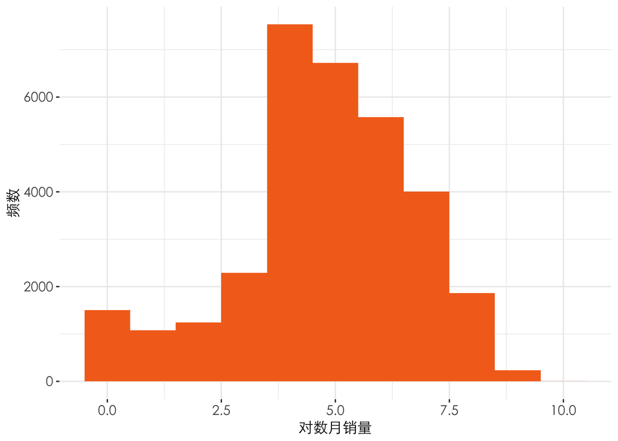

```r
ggplot(data) +
    geom_histogram(aes(x = log_recent_order_num), binwidth = 1, fill = "#f46f20") +
    labs(y = "频数", x = "对数月销量") +
    theme_bw() +
    theme(panel.border = element_blank(),
          text = element_text(family = "STXihei"),
          axis.title = element_text(size = 12),
          axis.text = element_text(size = 11))
```

从对数月销量直方图中可以看出北京外卖商家的对数月销售量集中在0到10之间，呈明显的左偏趋势，表明存在少部分商家的对数月销量偏低，大部分的商家对数月销量都在3以上，但对数月销售量在9以上的商家较少，总之，北京外卖商家生意整体较好，爆单和冷门的商家较少。

# 3. 第三题

绘制行政区划与月销量对比箱线图，并作出解释（要求箱线图的箱子按中位数大小排列）；

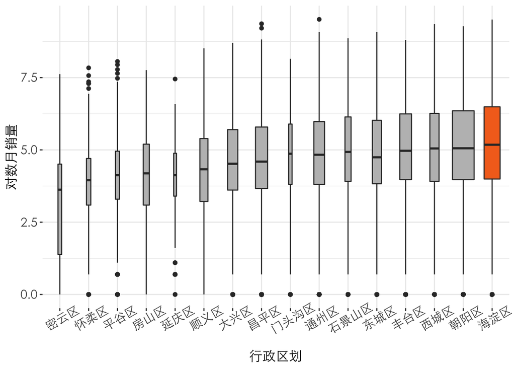

```r
# 将行政区域转化为因子类型
data$district <- factor(data$district)
# 按平均价格从低到高对等级进行排列
data$district <- reorder(data$district,data$log_recent_order_num, mean)

# 绘制箱线图
ggplot(data) +
  geom_boxplot(aes(x = district, y = log_recent_order_num), varwidth = T, fill = c(rep('grey',15),"#f46f20"))+
  labs(x = "行政区划", y = "对数月销量")+
  theme_bw() +
  theme(panel.border=element_blank(),
          text = element_text(family = "STXihei"),
          axis.title = element_text(size = 13),
          axis.text = element_text(size = 12),
          axis.text.x = element_text(angle = 30, hjust = 0.5))
```

从行政区划的箱线图可以看出，整体上外卖的销量与所处的地理位置是呈正相关的，北京城六区的销售量大于非城区的销量，越繁华的城区，例如海淀区和朝阳区其外卖销量越高。从“箱”的宽度可以看到朝阳区的外卖销量是最多的，从“箱”高可以发现每个行政区域的销量波动水平比较接近。

# 4. 第四题

绘制四个用餐高峰期是否营业（open08、open12、open18、open23）与对数月销量对比箱线图（四个子图）。

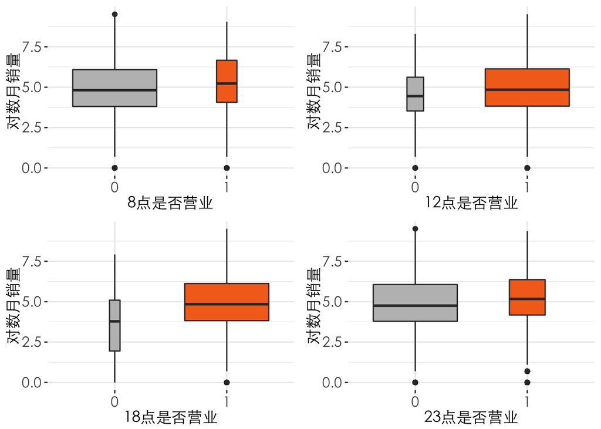

```r
library(ggpubr)
# 绘制箱线图
p1 <- ggplot(data) +
  geom_boxplot(aes(x = as.factor(open08), y = log_recent_order_num), varwidth = T, fill = c('grey',"#f46f20"))+
  labs(x = "8点是否营业", y = "对数月销量")+
  theme_bw() +
  theme(panel.border=element_blank(),
          text = element_text(family = "STXihei"),
          axis.title = element_text(size = 13),
          axis.text = element_text(size = 12))
p2 <- ggplot(data) +
  geom_boxplot(aes(x = as.factor(open12), y = log_recent_order_num), varwidth = T, fill = c('grey',"#f46f20"))+
  labs(x = "12点是否营业", y = "对数月销量")+
  theme_bw() +
  theme(panel.border=element_blank(),
          text = element_text(family = "STXihei"),
          axis.title = element_text(size = 13),
          axis.text = element_text(size = 12))
p3 <- ggplot(data) +
  geom_boxplot(aes(x = as.factor(open18), y = log_recent_order_num), varwidth = T, fill = c('grey',"#f46f20"))+
  labs(x = "18点是否营业", y = "对数月销量")+
  theme_bw() +
  theme(panel.border=element_blank(),
          text = element_text(family = "STXihei"),
          axis.title = element_text(size = 13),
          axis.text = element_text(size = 12))
p4 <- ggplot(data) +
  geom_boxplot(aes(x = as.factor(open23), y = log_recent_order_num), varwidth = T, fill = c('grey',"#f46f20"))+
  labs(x = "23点是否营业", y = "对数月销量")+
  theme_bw() +
  theme(panel.border=element_blank(),
          text = element_text(family = "STXihei"),
          axis.title = element_text(size = 13),
          axis.text = element_text(size = 12))
ggarrange(p1,p2,p3,p4, ncol=2, nrow = 2)
```

从箱线图可以看出，18点是一个非常关键的时间节点，非常影响外卖的销售量。

# 5. 第五题

建立回归模型，使用BIC准则进行逐步回归得到最终模型，查看最终模型中的系数大小及其显著性，并解读系数。

```r
data_rg <- data[,c('log_recent_order_num',"log_average_cost","log_float_delivery_fee","log_float_minimum_order_amount","order_lead_time","district","manjian_discount","other_activities","new_user","open_time","shop_type","delivery_mode","保","票","open08","open12","open18","open23","is_new","is_premium")]
data_rg$district <- factor(data_rg$district, levels = c("昌平区" ,"密云区" ,"怀柔区", "平谷区" ,"房山区",   "延庆区" , "顺义区" , "大兴区" ,"门头沟区","通州区" ,"石景山区" ,"东城区", "丰台区" ,  "西城区" ,  "朝阳区" ,  "海淀区" ))
data_rg$shop_type <- factor(data_rg$shop_type, levels = c("果蔬生鲜" ,"快餐简餐", "特色菜系", "甜品饮品", "小吃夜宵" ,"异国料理"))
# 其他定性变量
for ( i in c(12:20)){
  data_rg[,i] <- as.factor(data_rg[,i])
}
```

```r
## 建立线性模型
lm.fit1 = lm(log_recent_order_num~ ., data = data_rg)
## 查看回归结果
summary(lm.fit1)
```

```
##
## Call:
## lm(formula = log_recent_order_num ~ ., data = data_rg)
##
## Residuals:
##     Min      1Q  Median      3Q     Max
## -5.9349 -0.8153  0.0617  0.8994  4.3916
##
## Coefficients:
##                                 Estimate Std. Error t value Pr(>|t|)
## (Intercept)                     0.391641   0.104619   3.744 0.000182 ***
## log_average_cost                0.266842   0.007348  36.315  < 2e-16 ***
## log_float_delivery_fee         -0.309642   0.017478 -17.717  < 2e-16 ***
## log_float_minimum_order_amount -0.006716   0.009966  -0.674 0.500401
## order_lead_time                 0.038597   0.000669  57.695  < 2e-16 ***
## district密云区                 -0.570341   0.091147  -6.257 3.97e-10 ***
## district怀柔区                 -0.287581   0.081611  -3.524 0.000426 ***
## district平谷区                 -0.043142   0.086883  -0.497 0.619508
## district房山区                 -0.396542   0.055057  -7.202 6.05e-13 ***
## district延庆区                  0.140768   0.114276   1.232 0.218024
## district顺义区                 -0.183918   0.044622  -4.122 3.77e-05 ***
## district大兴区                 -0.031652   0.039360  -0.804 0.421299
## district门头沟区                0.297286   0.091554   3.247 0.001167 **
## district通州区                  0.283771   0.037405   7.586 3.38e-14 ***
## district石景山区                0.084339   0.054727   1.541 0.123306
## district东城区                 -0.126423   0.042817  -2.953 0.003153 **
## district丰台区                  0.037726   0.036461   1.035 0.300824
## district西城区                 -0.054247   0.042251  -1.284 0.199174
## district朝阳区                  0.034924   0.029523   1.183 0.236834
## district海淀区                  0.010957   0.031695   0.346 0.729564
## manjian_discount                3.911180   0.049186  79.518  < 2e-16 ***
## other_activities                0.093194   0.004535  20.550  < 2e-16 ***
## new_user                        0.001198   0.002354   0.509 0.610846
## open_time                       0.062182   0.004823  12.893  < 2e-16 ***
## shop_type快餐简餐               0.919751   0.040043  22.969  < 2e-16 ***
## shop_type特色菜系               0.447415   0.041034  10.904  < 2e-16 ***
## shop_type甜品饮品               0.437965   0.047284   9.262  < 2e-16 ***
## shop_type小吃夜宵               0.739152   0.041803  17.682  < 2e-16 ***
## shop_type异国料理               0.633310   0.047377  13.367  < 2e-16 ***
## delivery_mode商家配送           0.163623   0.019173   8.534  < 2e-16 ***
## 保TRUE                          0.110541   0.024034   4.599 4.25e-06 ***
## 票TRUE                          0.263976   0.018889  13.975  < 2e-16 ***
## open081                        -0.028024   0.043670  -0.642 0.521053
## open121                         0.005202   0.051842   0.100 0.920074
## open181                         0.343339   0.066238   5.183 2.19e-07 ***
## open231                         0.111026   0.030873   3.596 0.000323 ***
## is_newTrue                     -1.474400   0.028790 -51.212  < 2e-16 ***
## is_premiumTrue                  0.915124   0.026312  34.780  < 2e-16 ***
## ---
## Signif. codes:  0 '***' 0.001 '**' 0.01 '*' 0.05 '.' 0.1 ' ' 1
##
## Residual standard error: 1.331 on 32005 degrees of freedom
## Multiple R-squared:  0.5346, Adjusted R-squared:  0.5341
## F-statistic: 993.7 on 37 and 32005 DF,  p-value: < 2.2e-16
```

```r
## 使用BIC准则选择模型
n <- nrow(data_rg)
lm.bic <- step(lm.fit1, direction = "both", k = log(n), trace = F)
summary(lm.bic)
```

```
##
## Call:
## lm(formula = log_recent_order_num ~ log_average_cost + log_float_delivery_fee +
##     order_lead_time + district + manjian_discount + other_activities +
##     open_time + shop_type + delivery_mode + 保 + 票 + open18 +
##     open23 + is_new + is_premium, data = data_rg)
##
## Residuals:
##     Min      1Q  Median      3Q     Max
## -5.9367 -0.8157  0.0620  0.9003  4.3921
##
## Coefficients:
##                          Estimate Std. Error t value Pr(>|t|)
## (Intercept)             0.3990967  0.0865210   4.613 3.99e-06 ***
## log_average_cost        0.2668911  0.0073315  36.403  < 2e-16 ***
## log_float_delivery_fee -0.3102244  0.0173775 -17.852  < 2e-16 ***
## order_lead_time         0.0386588  0.0006644  58.184  < 2e-16 ***
## district密云区         -0.5858945  0.0864320  -6.779 1.23e-11 ***
## district怀柔区         -0.3024593  0.0753948  -4.012 6.04e-05 ***
## district平谷区         -0.0640392  0.0806954  -0.794  0.42744
## district房山区         -0.3978019  0.0550011  -7.233 4.84e-13 ***
## district延庆区          0.1195407  0.1086993   1.100  0.27145
## district顺义区         -0.1842610  0.0445789  -4.133 3.58e-05 ***
## district大兴区         -0.0314157  0.0393380  -0.799  0.42452
## district门头沟区        0.2970940  0.0915206   3.246  0.00117 **
## district通州区          0.2839959  0.0373852   7.596 3.13e-14 ***
## district石景山区        0.0839381  0.0547053   1.534  0.12495
## district东城区         -0.1260826  0.0427856  -2.947  0.00321 **
## district丰台区          0.0371510  0.0364244   1.020  0.30776
## district西城区         -0.0544237  0.0422201  -1.289  0.19739
## district朝阳区          0.0345394  0.0294999   1.171  0.24167
## district海淀区          0.0104325  0.0316719   0.329  0.74186
## manjian_discount        3.9118711  0.0486803  80.358  < 2e-16 ***
## other_activities        0.0930431  0.0045140  20.612  < 2e-16 ***
## open_time               0.0610309  0.0033728  18.095  < 2e-16 ***
## shop_type快餐简餐       0.9234872  0.0397257  23.247  < 2e-16 ***
## shop_type特色菜系       0.4506565  0.0407715  11.053  < 2e-16 ***
## shop_type甜品饮品       0.4407513  0.0471023   9.357  < 2e-16 ***
## shop_type小吃夜宵       0.7420333  0.0412015  18.010  < 2e-16 ***
## shop_type异国料理       0.6365183  0.0472139  13.482  < 2e-16 ***
## delivery_mode商家配送   0.1640758  0.0191332   8.575  < 2e-16 ***
## 保TRUE                  0.1101934  0.0237518   4.639 3.51e-06 ***
## 票TRUE                  0.2635722  0.0188281  13.999  < 2e-16 ***
## open181                 0.3536137  0.0640169   5.524 3.34e-08 ***
## open231                 0.1109112  0.0270153   4.105 4.04e-05 ***
## is_newTrue             -1.4763716  0.0283226 -52.127  < 2e-16 ***
## is_premiumTrue          0.9139038  0.0253116  36.106  < 2e-16 ***
## ---
## Signif. codes:  0 '***' 0.001 '**' 0.01 '*' 0.05 '.' 0.1 ' ' 1
##
## Residual standard error: 1.33 on 32009 degrees of freedom
## Multiple R-squared:  0.5346, Adjusted R-squared:  0.5341
## F-statistic:  1114 on 33 and 32009 DF,  p-value: < 2.2e-16
```

模型的F检验的p值小于0.001，表明模型设定基本合理。调整后的R方约为0.535，作为社会经济领域的解释性模型，R²值可以接受。

(2)位置信息

在行政区划方面，只有密云区、怀柔区、房山区、顺义区、门头沟区、通州区、东城区7个变量的系数估计值显著，其中只有门头沟区、通州区系数为正，分别为0.297和0.284，表明在其他因素不变的情况下，门头沟区和通州区的外卖对数月销量比基准组(昌平区)高出29.7%和28.4%。密云区的系数估计值最小，为-0.586，表明在其他因素不变的情况下，密云区的外卖对数月销量比基准组(昌平区)低一半左右。

(3)优惠信息

在优惠信息方面，满减折扣率和其他活动数量均对外卖销量有促进作用，其中满减折扣率的促进作用最明显，在其他条件不变的情况下，每增加一个单位的折扣率就能使得对数月销售量增加4单。

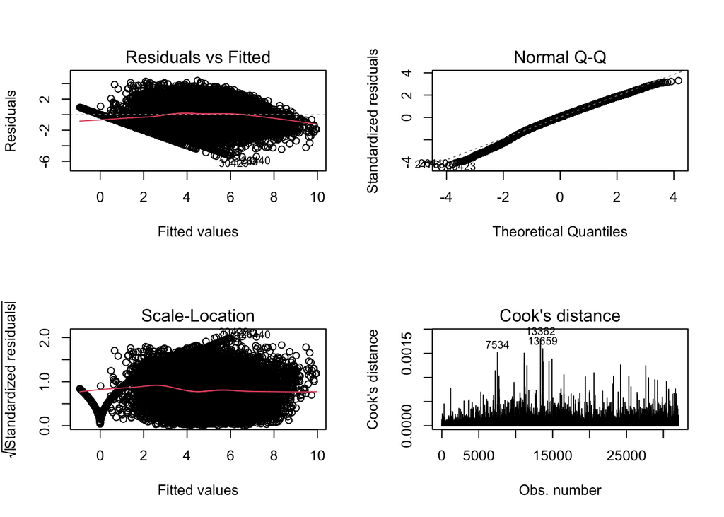

```r
# 将画布分为2*2的4块
par(mfrow=c(2,2))
plot(lm.bic, which = c(1:4))
```

```r
# 多重共线性诊断：计算VIF值
library(DAAG)
vif(lm.bic)
```

```
##       log_average_cost log_float_delivery_fee        order_lead_time
##                 1.1863                 1.2330                 1.2162
##         district密云区         district怀柔区         district平谷区
##                 1.1465                 1.2058                 1.1690
##         district房山区         district延庆区         district顺义区
##                 1.2305                 1.0957                 1.3951
##         district大兴区       district门头沟区         district通州区
##                 1.7041                 1.0758                 1.6884
##       district石景山区         district东城区         district丰台区
##                 1.2319                 1.6268                 1.8762
##         district西城区         district朝阳区         district海淀区
##                 1.6067                 3.2593                 2.4417
##       manjian_discount       other_activities              open_time
##                 1.2599                 1.3687                 1.6295
##      shop_type快餐简餐      shop_type特色菜系      shop_type甜品饮品
##                 7.0388                 4.9643                 2.4280
##      shop_type小吃夜宵      shop_type异国料理  delivery_mode商家配送
##                 4.3528                 2.3095                 1.6153
##                 保TRUE                 票TRUE                open181
##                 1.9691                 1.2480                 1.1261
##                open231             is_newTrue         is_premiumTrue
##                 1.7173                 1.1302                 1.3363
```

图中所示残差并不随着拟合值的变化呈现规律性变化，因此基本满足线性假设。图中散点大部分落在呈45度倾斜的直线上，满足正态性；水平线周围的点应呈现无规律随机分布，不存在异方差问题；样本点的库克距离最大值未超过0.002，因此认为样本中不存在异常点。在多重共线性诊断中VIF<10，推断不存在多重共线性。

# 6. 第六题

```r
# summary(lm.bic)$coefficients[c(5:19),]
```

```r
cof <- as.data.frame(summary(lm.bic)$coefficients[c(5:19),c(1,4)])
colnames(cof) <- c('estimate',"p_value")
cof$district <- rownames(cof)
for (i in 1:nrow(cof)){
  # 设置横坐标
  cof[i,3] <- substring(cof[i,3],9)
}
# 设置显著性标签
cof$label <- cut(cof$p_value, breaks = c(-Inf,0.05,Inf), labels=c("显著","不显著"))
```

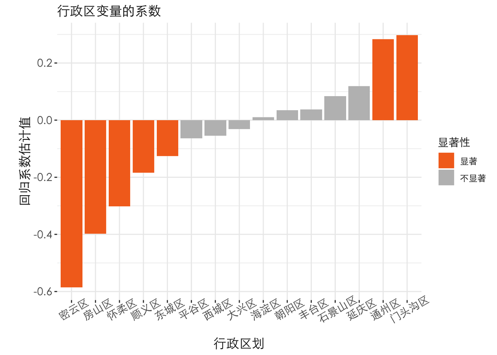

```r
cof$district <- factor(cof$district)

ggplot(cof) +
    geom_bar(aes(x = reorder(district,estimate), y = estimate, fill = label),
      show.legend = T, stat = 'identity', position = 'stack') +
    scale_fill_manual("显著性", values = c( "#f46f20","grey")) +    # 显著性结果填色
    labs(x = "行政区划", y = "\n回归系数估计值", title = "行政区变量的系数") +
    theme_bw() +
    theme(panel.border=element_blank(),
          text = element_text(family = "STXihei"),
          axis.title = element_text(size = 13),
          axis.text = element_text(size = 11),
          axis.text.x = element_text(angle = 30, hjust = 0.5))
```

# 7. 第七题

假设你要开一家外卖店，并有如下打算，请预测其未来的（已经不是新店）月销量。

```r
# 新样本
testdata0 <- data.frame(district="朝阳区",shop_type="快餐简餐",is_new="False",is_premium = "False",delivery_mode = "蜂鸟专送",保="TRUE",票= "FALSE",open18=1,open23=1,log_average_cost = log(21),log_float_delivery_fee = log(7),order_lead_time = 45, manjian_discount = 0.35, other_activities = 5, open_time=11)

# 变成因子类型
for (i in 1:9){
  testdata0[,i]<-as.factor(testdata0[,i])
}
```

```r
logsalary_hat <- predict(lm.bic, newdata = testdata0)  # 预测值
sigma_hat2 <- sum(lm.bic$residuals^2)/lm.bic$df.residual  # sigma^2估计值
y_hat <- exp(logsalary_hat + sigma_hat2/2)  #
cat("未来月销量约为", round(y_hat, 2), "单")
```

```
## 未来月销量约为 1438.21 单
```